# Alfredo_Credito

## Contexto

Para minimizar as perdas do ponto de vista do banco, o banco precisa de uma regra de decisão sobre quem deve aprovar o empréstimo e a quem não deve. Os perfis demográficos e socioeconómicos de um requerente são considerados pelos gestores de crédito antes de ser tomada uma decisão relativamente ao seu pedido de empréstimo. Neste conjunto de dados, cada entrada representa uma pessoa que recebe crédito de um banco. Cada pessoa é classificada como tendo um risco de crédito bom ou mau de acordo com o conjunto de atributos.

## Objetivo

O objetivo é construir um modelo preditivo com base nestes dados para ajudar o banco a decidir se deve aprovar um empréstimo a um potencial candidato ou não.

### Descrição dos dados:

- Age (Numeric: Age in years)
- Sex (Categories: male, female)
- Job (Categories: unskilled and non-resident, unskilled and resident, skilled, highly skilled)
- Housing (Categories: own, rent, or free)
- Saving accounts (Categories: little, moderate, quite rich, rich)
- Checking account (Categories: little, moderate, rich)
- Credit amount (Numeric: Amount of credit in Dallares)
- Duration (Numeric: Duration for which the credit is given in months)
- Purpose (Categories: car, furniture/equipment,radio/TV, domestic appliances, repairs, education, business, vacation/others)
- Risk (0 - Person is not at risk, 1 - Person is at risk(defaulter))

**Importando bibliotecas necessárias**

```python
# Data manupulation libraries
import pandas as pd
import numpy as np
from sklearn.model_selection import train_test_split

# Visualization libraries
import seaborn as sns
import matplotlib.pyplot as plt

# Machine learning models libraries
from sklearn.tree import DecisionTreeClassifier

# Scoring libraries (check your results)
from sklearn.metrics import confusion_matrix
from sklearn.metrics import classification_report

# Library to split data
from sklearn.model_selection import train_test_split


# To build linear model for statistical analysis and prediction
import statsmodels.stats.api as sms
from statsmodels.stats.outliers_influence import variance_inflation_factor
import statsmodels.api as sm
from statsmodels.tools.tools import add_constant

# To get diferent metric scores
from sklearn import metrics
from sklearn.metrics import accuracy_score, roc_curve, confusion_matrix, roc_auc_score
```

**Carregando e Explorando os Dados**

```python
data = pd.read_csv(r"C:\Users\j040m\Music\CURSO\trabalho final\nº1\Credito.csv")
```

```python
data['Job'] = data['Job'].replace({'unskilled_and_non-resident': 'Sem formação',
    'skilled': 'formação técnica', 'highly skilled':'formação superior'})
data['Housing'] = data['Housing'].replace({'free': 'Sem casa',
    'own': 'Casa Propria', 'rent':'casa arrendada'})
data['Saving accounts'] = data['Saving accounts'].replace({'little': 'pouca',
    'moderate': 'moderada', 'quite rich':'boa','rich':'muito boa'})
data['Checking account'] = data['Checking account'].replace({'little': 'pouca',
    'moderate': 'moderada', 'quite rich':'boa','rich':'muito boa'})
data['Sex'] = data['Sex'].replace({'male': 'Homem', 'female': 'Mulher'})
data['Purpose'] = data['Purpose'].replace({'Business': 'Negócios',
    'domestic appliances': 'Aplicação domesticas', 'education':'Educação',
    'repairs':'reparação','vacation/others':'ferias/outros','car':'carro',
    'furniture/equipment':'Equipamento/Mobilias'})
```

**Visualizando as primeiras e últimas 5 linhas do conjunto de dados**

```python
data.head()
```

|  | Age | Sex | Job | Housing | Saving accounts | Checking account | Credit amount | Duration | Risk | Purpose |
| --- | --- | --- | --- | --- | --- | --- | --- | --- | --- | --- |
| 0 | 67 | Homem | formação técnica | Casa Propria | pouca | pouca | 1169 | 6 | 0 | radio/TV |
| 1 | 22 | Mulher | formação técnica | Casa Propria | pouca | moderada | 5951 | 48 | 1 | radio/TV |
| 2 | 49 | Homem | Sem formação | Casa Propria | pouca | pouca | 2096 | 12 | 0 | Educação |
| 3 | 45 | Homem | formação técnica | Sem casa | pouca | pouca | 7882 | 42 | 0 | Equipamento/Mobilias |
| 4 | 53 | Homem | formação técnica | Sem casa | pouca | pouca | 4870 | 24 | 1 | carro |

```python
data.tail()
```

|  | Age | Sex | Job | Housing | Saving accounts | Checking account | Credit amount | Duration | Risk | Purpose |
| --- | --- | --- | --- | --- | --- | --- | --- | --- | --- | --- |
| 995 | 31 | Mulher | Sem formação | Casa Propria | pouca | pouca | 1736 | 12 | 0 | Equipamento/Mobilias |
| 996 | 40 | Homem | formação superior | Casa Propria | pouca | pouca | 3857 | 30 | 0 | carro |
| 997 | 38 | Homem | formação técnica | Casa Propria | pouca | pouca | 804 | 12 | 0 | radio/TV |
| 998 | 23 | Homem | formação técnica | Sem casa | pouca | pouca | 1845 | 45 | 1 | radio/TV |
| 999 | 27 | Homem | formação técnica | Casa Propria | moderada | moderada | 4576 | 45 | 0 | carro |

**Entendendo a forma do conjunto de dados**

```python
# Verifica o tamanho dos dados
print(f'O tamanho de dados é de: {data.shape}\n')
```

```
O tamanho de dados é de: (1000, 10)
```

**Verificando os valores nulos e duplicados nos dados**

```python
data.duplicated().sum().any()
```

```
False
```

```python
data.isnull().sum()
```

```
Age                 0
Sex                 0
Job                 0
Housing             0
Saving accounts     0
Checking account    0
Credit amount       0
Duration            0
Risk                0
Purpose             0
dtype: int64
```

- Observa-se que não existem valores nulos e duplicados

**Verificando os tipos de dados das variaveis para o conjunto de dados**

```python
data.info()
```

```
<class 'pandas.core.frame.DataFrame'>
RangeIndex: 1000 entries, 0 to 999
Data columns (total 10 columns):
 #   Column            Non-Null Count  Dtype
---  ------            --------------  -----
 0   Age               1000 non-null   int64
 1   Sex               1000 non-null   object
 2   Job               1000 non-null   object
 3   Housing           1000 non-null   object
 4   Saving accounts   1000 non-null   object
 5   Checking account  1000 non-null   object
 6   Credit amount     1000 non-null   int64
 7   Duration          1000 non-null   int64
 8   Risk              1000 non-null   int64
 9   Purpose           1000 non-null   object
dtypes: int64(4), object(6)
memory usage: 78.3+ KB
```

- Há 4 variaveis numéricas do tipo int e 6 de tipo de objeto.

**verificando o resumo estatístico dos dados.**

```python
data.describe().T
```

|  | count | mean | std | min | 25% | 50% | 75% | max |
| --- | --- | --- | --- | --- | --- | --- | --- | --- |
| Age | 1000.0 | 35.546 | 11.375469 | 19.0 | 27.0 | 33.0 | 42.00 | 75.0 |
| Credit amount | 1000.0 | 3271.258 | 2822.736876 | 250.0 | 1365.5 | 2319.5 | 3972.25 | 18424.0 |
| Duration | 1000.0 | 20.903 | 12.058814 | 4.0 | 12.0 | 18.0 | 24.00 | 72.0 |
| Risk | 1000.0 | 0.300 | 0.458487 | 0.0 | 0.0 | 0.0 | 1.00 | 1.0 |

```python
# Verificando a quantidade de valores em todas as variavel
for i in data.columns:
    print(i,len(data[i].unique()))
```

```
Age 53
Sex 2
Job 3
Housing 3
Saving accounts 4
Checking account 3
Credit amount 921
Duration 33
Risk 2
Purpose 8
```

# Análise exploratória de dados

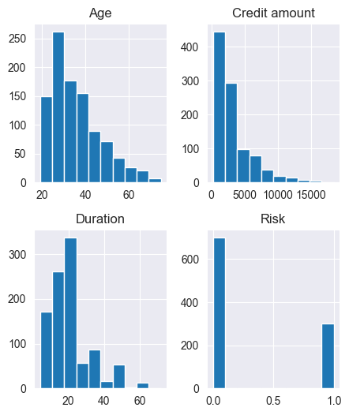

```python
sns.set_style("darkgrid")
data.hist(figsize=(5, 6))
plt.show()
```

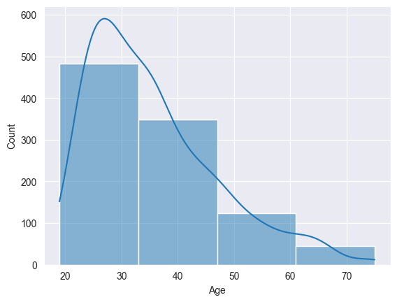

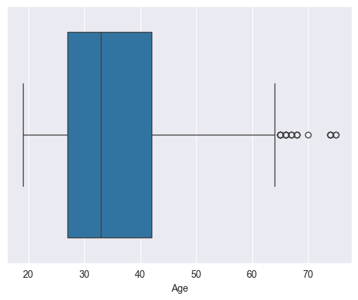

```python
a=data[data['Age']!=0]
sns.histplot(data=a,x='Age',bins=4, stat='count', kde=True)
plt.show()
sns.boxplot(data = a, x='Age')
plt.show()
```

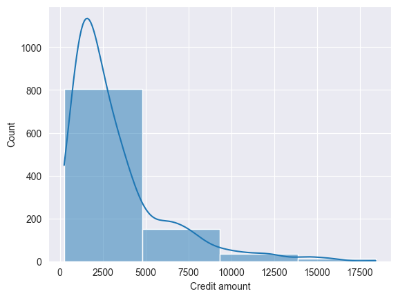

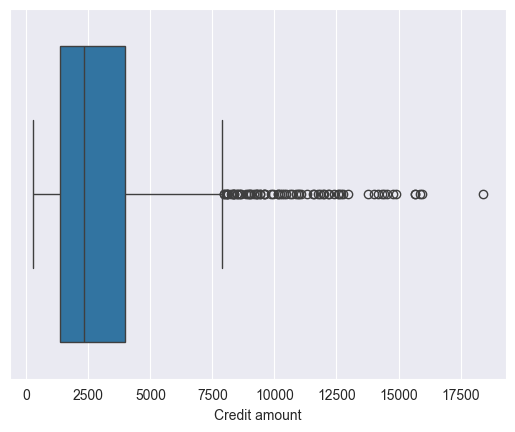

```python
a=data[data['Credit amount']!=0]
sns.histplot(data=a,x='Credit amount',bins=4, stat='count', kde=True)
plt.show()
sns.boxplot(data = a, x='Credit amount')
plt.show()
```

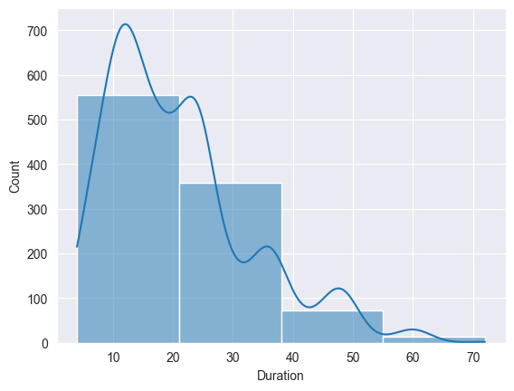

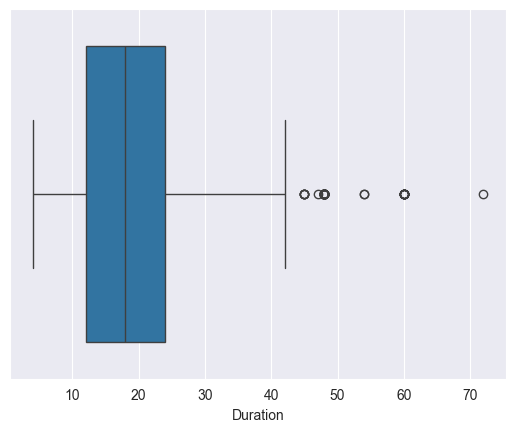

```python
a=data[data['Duration']!=0]
sns.histplot(data=a,x='Duration',bins=4, stat='count', kde=True)
plt.show()
sns.boxplot(data = a, x='Duration')
plt.show()
```

```python
data["Sex"].value_counts()
```

```
Sex
Homem     690
Mulher    310
Name: count, dtype: int64
```

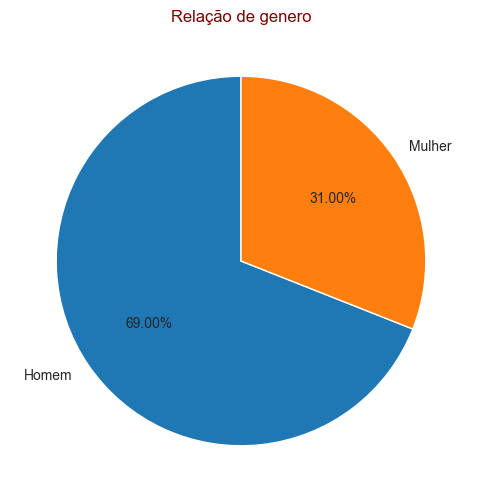

```python
a=data["Sex"].value_counts().tolist()
b=data["Sex"].unique().tolist()
plt.figure(figsize=(8,6))
plt.pie(a, labels=b,  autopct="%0.2f%%", startangle=90)
plt.title("Relação de genero", color="Maroon")
plt.show()
```

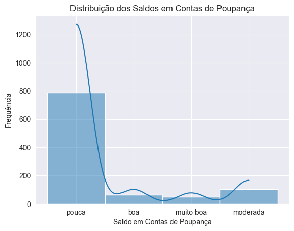

```python
# Distribuição dos saldos em contas de poupança
sns.histplot(data['Saving accounts'], bins=30, kde=True)
plt.title('Distribuição dos Saldos em Contas de Poupança')
plt.xlabel('Saldo em Contas de Poupança')
plt.ylabel('Frequência')
plt.show()
```

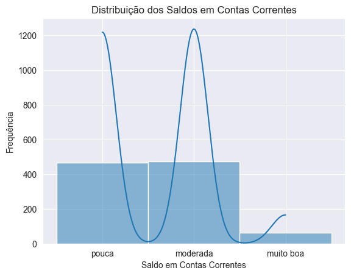

```python
# Distribuição dos saldos em contas correntes
sns.histplot(data['Checking account'], bins=30, kde=True)
plt.title('Distribuição dos Saldos em Contas Correntes')
plt.xlabel('Saldo em Contas Correntes')
plt.ylabel('Frequência')
plt.show()
```

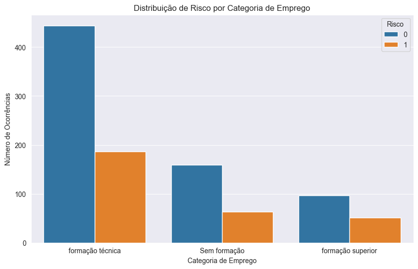

```python
# Plotar a distribuição de risco por categoria de emprego
plt.figure(figsize=(10, 6))
sns.countplot(data=data, x='Job', hue='Risk')
plt.title('Distribuição de Risco por Categoria de Emprego')
plt.xlabel('Categoria de Emprego')
plt.ylabel('Número de Ocorrências')
plt.legend(title='Risco', loc='upper right')
plt.show()
```

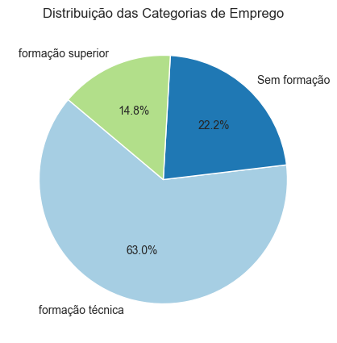

```python
# Contar a frequência de cada categoria de 'Job'
job_counts = data['Job'].value_counts()

# Plotar o gráfico de pizza
plt.figure(figsize=(5, 5))
plt.pie(job_counts, labels=job_counts.index, autopct='%1.1f%%', startangle=140, colors=plt.cm.Paired(range(len(job_counts))))
plt.title('Distribuição das Categorias de Emprego')
plt.show()
```

```python
data["Job"].value_counts()
```

```
Job
formação técnica     630
Sem formação         222
formação superior    148
Name: count, dtype: int64
```

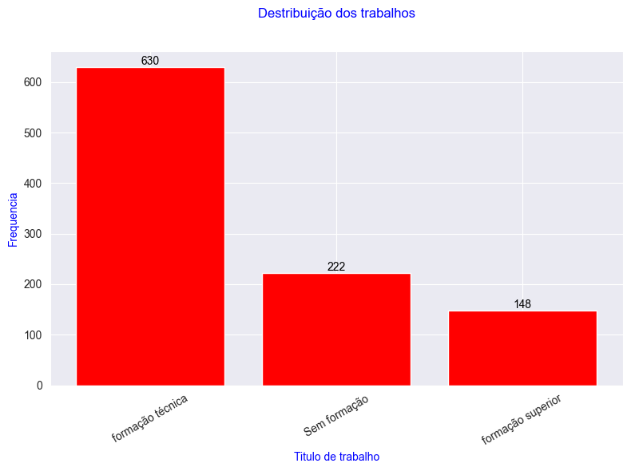

```python
a=data["Job"].value_counts().tolist()
b=data["Job"].unique().tolist()
plt.figure(figsize=(8,6))
bar = plt.bar(b,a,color='red')
plt.title('Destribuição dos trabalhos', color='blue', pad=30)
plt.xlabel('Titulo de trabalho', color='blue')
plt.ylabel('Frequencia', color='blue')
for bar, value in zip(bar, a):
    plt.text(bar.get_x() + bar.get_width()/2, bar.get_height(),
             value, ha='center', va='bottom', color='black')
plt.xticks(rotation=30)
plt.tight_layout()
plt.show()
```

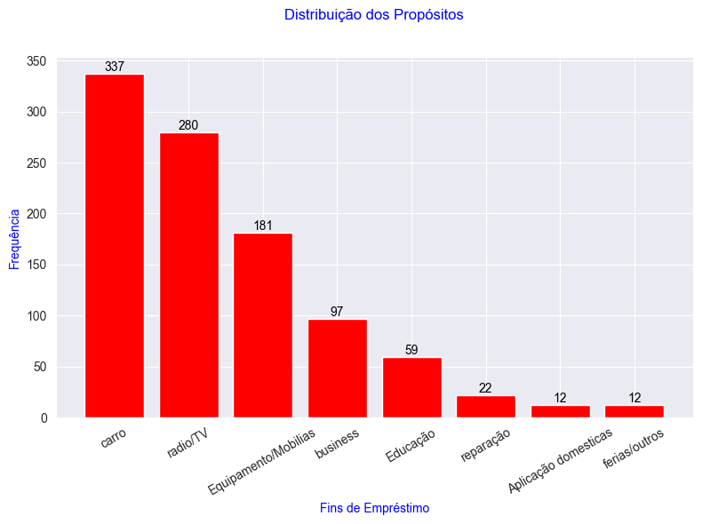

```python
a = data["Purpose"].value_counts().tolist()
b = data["Purpose"].value_counts().index.tolist()
plt.figure(figsize=(8, 6))
bars = plt.bar(b, a, color='red')
plt.title('Distribuição dos Propósitos', color='blue', pad=30)
plt.xlabel('Fins de Empréstimo', color='blue')
plt.ylabel('Frequência', color='blue')
for bar in bars:
    yval = bar.get_height()
    plt.text(bar.get_x() + bar.get_width()/2, yval, int(yval),
             ha='center', va='bottom', color='black')
plt.xticks(rotation=30)
plt.tight_layout()
plt.show()
```

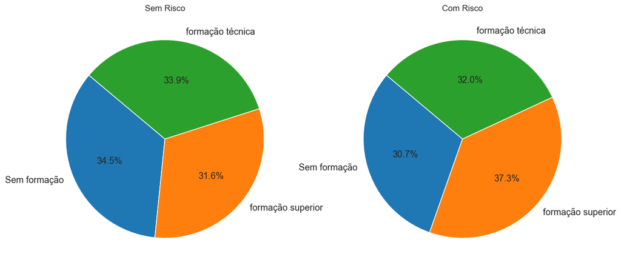

```python
gender_risk_distribution = data.groupby(['Job', 'Risk']).size(
).unstack().fillna(0)
gender_risk_distribution = gender_risk_distribution.div(
        gender_risk_distribution.sum(axis=1), axis=0)
fig, axes = plt.subplots(1, 2, figsize=(14, 7))
axes[0].pie(gender_risk_distribution.loc[:, 0],
            labels=gender_risk_distribution.index,
            autopct='%1.1f%%', startangle=140, textprops=dict(fontsize=13))
axes[0].set_title('Sem Risco')
axes[1].pie(gender_risk_distribution.loc[:, 1],
            labels=gender_risk_distribution.index,
            autopct='%1.1f%%', startangle=140, textprops=dict(fontsize=13))
axes[1].set_title('Com Risco')
plt.show()
```

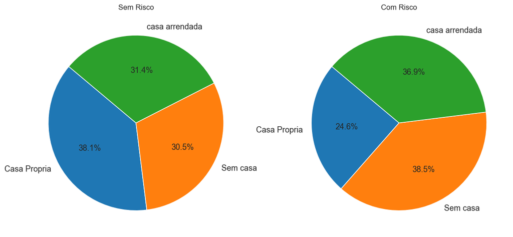

```python
gender_risk_distribution = data.groupby(['Housing', 'Risk']).size(
).unstack().fillna(0)
gender_risk_distribution = gender_risk_distribution.div(
        gender_risk_distribution.sum(axis=1), axis=0)
fig, axes = plt.subplots(1, 2, figsize=(14, 7))
axes[0].pie(gender_risk_distribution.loc[:, 0],
            labels=gender_risk_distribution.index,
            autopct='%1.1f%%', startangle=140, textprops=dict(fontsize=13))
axes[0].set_title('Sem Risco')
axes[1].pie(gender_risk_distribution.loc[:, 1],
            labels=gender_risk_distribution.index,
            autopct='%1.1f%%', startangle=140, textprops=dict(fontsize=13))
axes[1].set_title('Com Risco')
plt.show()
```

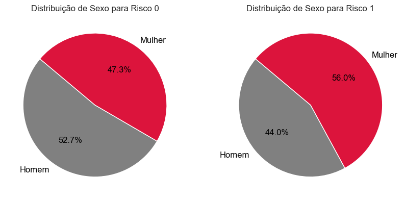

```python
gender_risk_distribution = data.groupby(['Sex', 'Risk']).size().unstack(
).fillna(0)
gender_risk_distribution = gender_risk_distribution.div(
    gender_risk_distribution.sum(axis=1), axis=0)
colors_risk_0 = ['#808080', '#DC143C'] ;colors_risk_1 = ['#808080', '#DC143C']
text_color_risk_0 = 'black' ; text_color_risk_1 = 'black'
fig, axes = plt.subplots(1, 2, figsize=(10, 7))
axes[0].pie(
    gender_risk_distribution.loc[:, 0],
    labels=gender_risk_distribution.index,
    autopct='%1.1f%%', startangle=140,
    colors=colors_risk_0, textprops=dict(color=text_color_risk_0,fontsize=12))
axes[0].set_title('Distribuição de Sexo para Risco 0')
axes[1].pie(
    gender_risk_distribution.loc[:, 1],
    labels=gender_risk_distribution.index,
    autopct='%1.1f%%', startangle=140,
    colors=colors_risk_1, textprops=dict(color=text_color_risk_1,fontsize=12))
axes[1].set_title('Distribuição de Sexo para Risco 1')
plt.show()
```

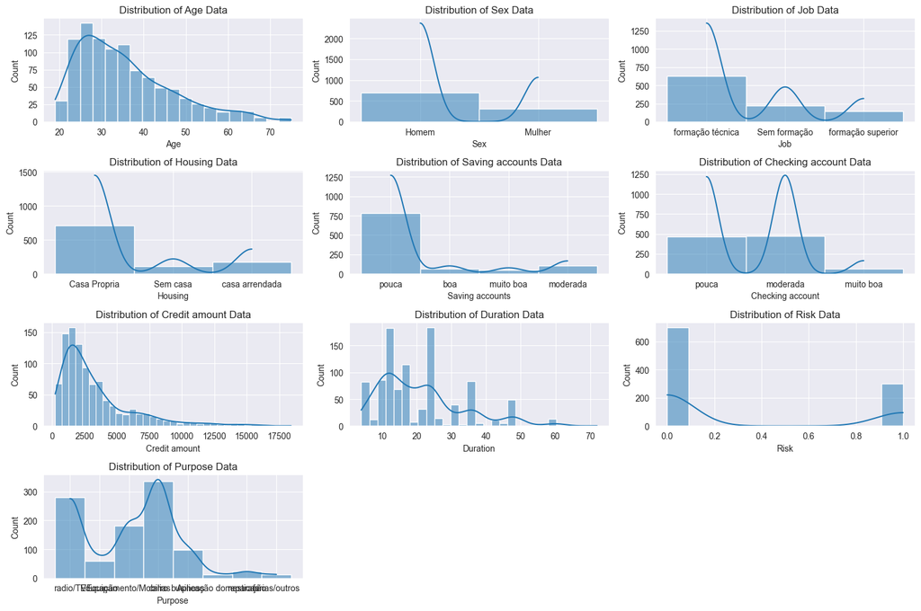

```python
# Agrupar os dados por 'Sex' e 'Risk' e contar o número de ocorrências
plt.figure(figsize=(15,10))
for i,col in enumerate(data.columns,1):
    plt.subplot(4,3,i)
    plt.title(f"Distribution of {col} Data")
    sns.histplot(data[col],kde=True)
    plt.tight_layout()
    plt.plot()
```

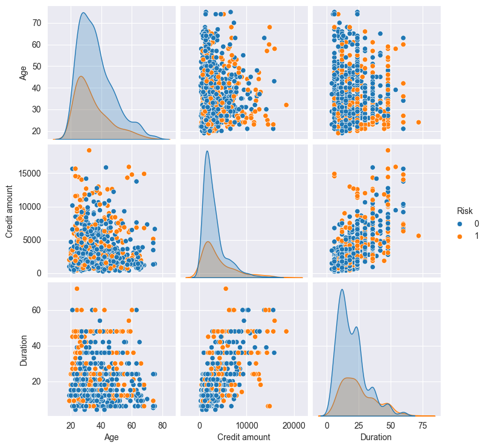

```python
sns.pairplot( data, hue="Risk")
plt.show()
```

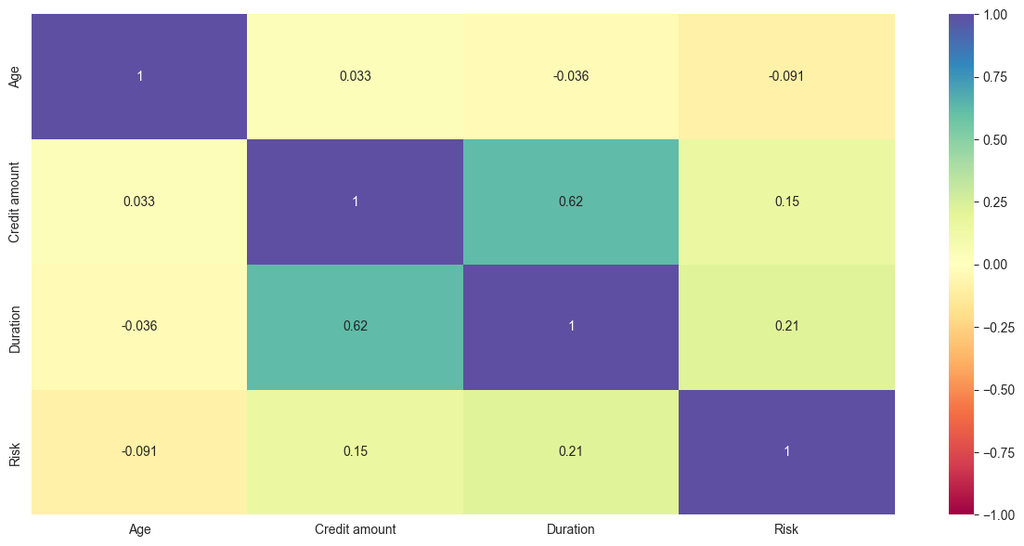

```python
plt.figure(figsize=(15,7))
sns.heatmap(data.select_dtypes(include="number").corr(),
            annot=True,cmap='Spectral',vmin=-1,vmax=1)
plt.show()
```

```python
data['amount per month'] = (data['Credit amount'] / data['Duration'])
data.head()
```

|  | Age | Sex | Job | Housing | Saving accounts | Checking account | Credit amount | Duration | Risk | Purpose | amount per month |
| --- | --- | --- | --- | --- | --- | --- | --- | --- | --- | --- | --- |
| 0 | 67 | Homem | formação técnica | Casa Propria | pouca | pouca | 1169 | 6 | 0 | radio/TV | 194.833333 |
| 1 | 22 | Mulher | formação técnica | Casa Propria | pouca | moderada | 5951 | 48 | 1 | radio/TV | 123.979167 |
| 2 | 49 | Homem | Sem formação | Casa Propria | pouca | pouca | 2096 | 12 | 0 | Educação | 174.666667 |
| 3 | 45 | Homem | formação técnica | Sem casa | pouca | pouca | 7882 | 42 | 0 | Equipamento/Mobilias | 187.666667 |
| 4 | 53 | Homem | formação técnica | Sem casa | pouca | pouca | 4870 | 24 | 1 | carro | 202.916667 |

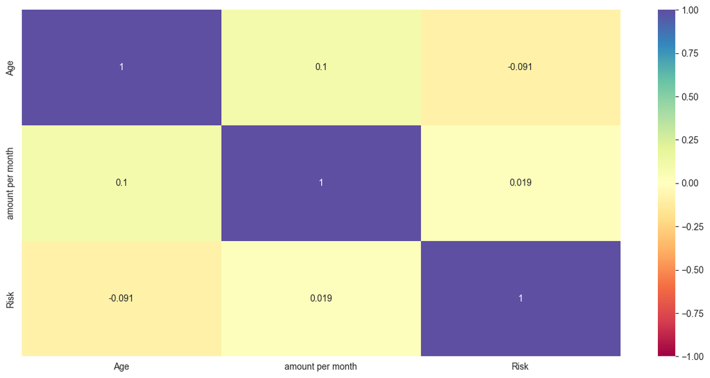

```python
plt.figure(figsize=(15,7))
sns.heatmap(data[['Age','amount per month','Risk']].select_dtypes(
    include="number").corr(),annot=True,cmap='Spectral',vmin=-1,vmax=1)
plt.show()
```

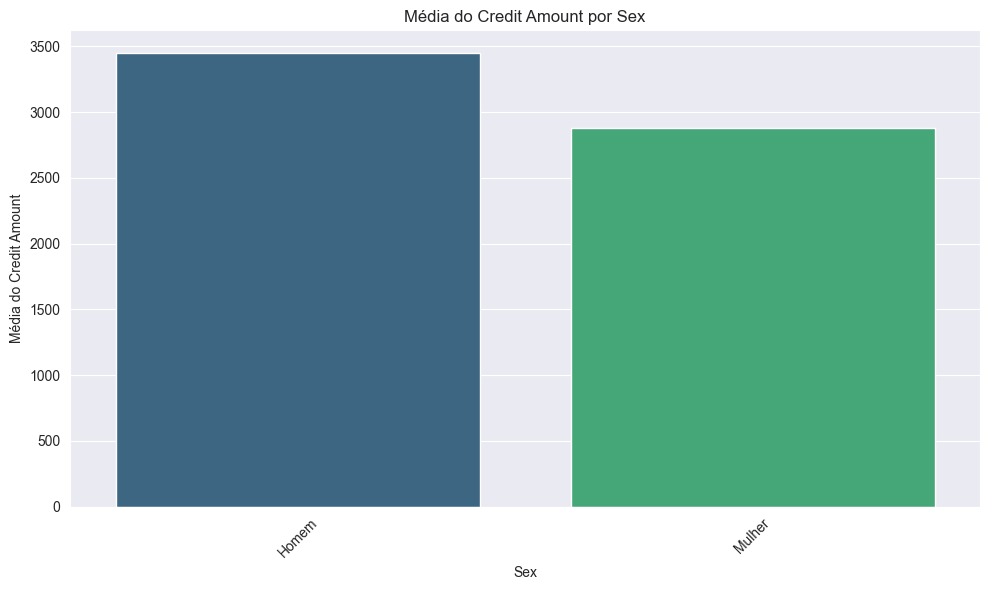

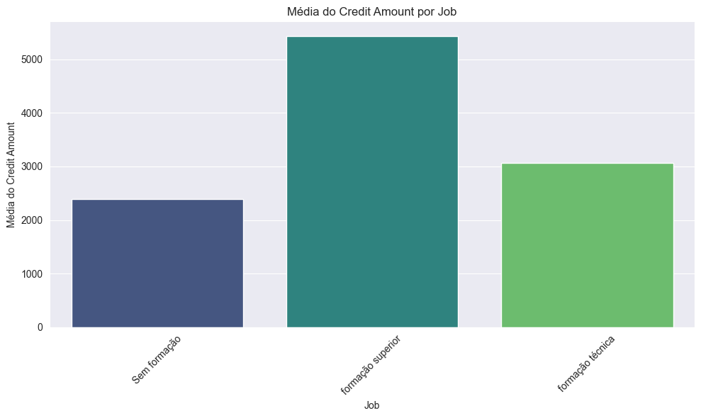

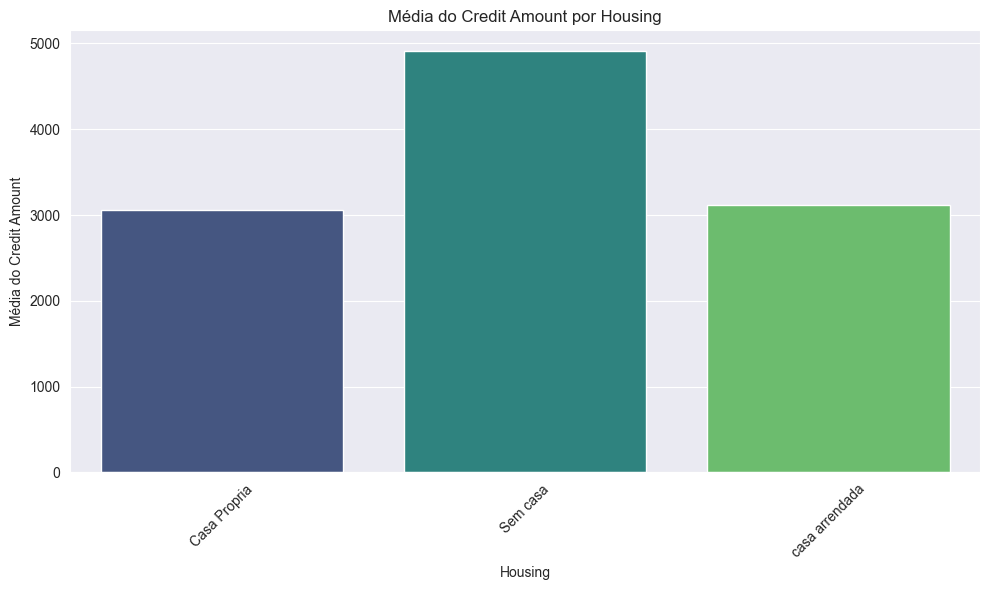

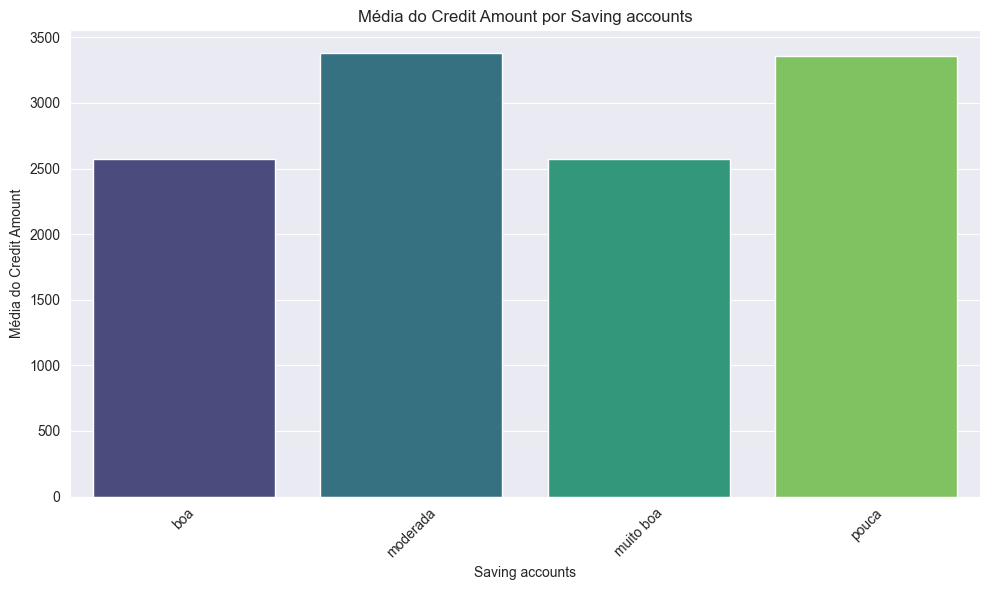

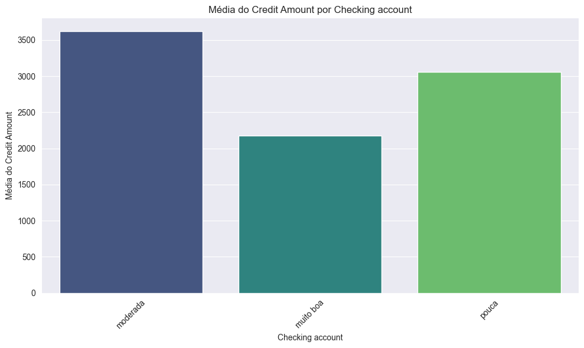

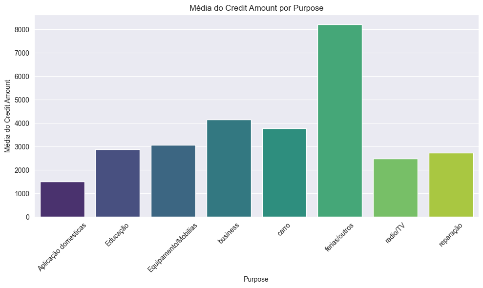

```python
# Identificar variáveis categóricas
categorical_vars = data.select_dtypes(include='object')
# Criar gráficos de barras separados para cada variável categórica
for column in categorical_vars.columns:
    plt.figure(figsize=(10, 6))
    # Calcular a média do `Credit amount` por categoria
    a = data.groupby(column)['Credit amount'].mean().reset_index()
    # Plotar o gráfico de barras
    sns.barplot(x=column, y='Credit amount', data=a,
                hue=column, palette='viridis')
    plt.title(f'Média do Credit Amount por {column}')
    plt.xticks(rotation=45)
    plt.xlabel(column)
    plt.ylabel('Média do Credit Amount')
    plt.tight_layout()
    plt.show()
```